# Notebook

```python
USE_CUDA = False  # Enable to use cudf instead of pandas
VERBOSE = False  # Additonal logging
EXTENTED_VIEW = False  # view additional data like model importances (SHAP is preferable due to reasons)
```

```python
import importlib
import matplotlib.pyplot as plt
import numpy as np
import pandas as pd
import seaborn as sns
from scipy.stats import chi2_contingency, pointbiserialr
from scipy.stats import normaltest, skew, kurtosis
from sklearn.model_selection import StratifiedKFold
from sklearn.preprocessing import StandardScaler
import shared.graph as graph
import shared.pipeline as pipeline_runner
import shared.stats_utils as stats_utils
import shared.utils as utils
import src.data_loader as data_loader
from src import model_config
import shared.definitions as model_defs
from shared import ml_config_core
import time
from typing import Dict
from shared.pipeline import ModelTrainingResult
import shap
import xgboost
from scipy.stats import spearmanr
from scipy.stats import kruskal
import numpy as np
import seaborn as sns
import matplotlib.pyplot as plt
from scipy.stats import gaussian_kde
from IPython.display import display, Markdown
import src.utils as utils
import shared.utils as shared_utils
```

```python
shared_utils.pandas_config(pd)
shared_utils.plt_config(plt)

sns.set_theme(style="darkgrid", palette="pastel")
plt.style.use("fivethirtyeight")
```

```python
source_df = data_loader.load_processed_dataset(
    sample_size=data_loader.SampleSize.Tiny,
    target_col="loan_status",
    target_type=utils.TargetType.Binary,
    # drop_cols=[]
)
```

```
With transform="pandas", `func` should return a DataFrame to follow the set_output API.
```

## 1.1 EDA

This is the exploratory analysis of the dataset and includes all the features shown in the (`Features`) notebook.

The EDA was done in parallel with model design process to minimize the influence analyzing manually analyzing the interaction between features might have had on our model design process.

#### Data selection

- `target_loan_status`: whether the loan applicant has defaulted on their loan (0 or 1)
- `pass_grade`: the grade assigned to the loan by the "Lenders Club" (A,B,C,D etc.)
- `pass_interest_rate`: the interest rate set for the loan (converted to float)

```python
if VERBOSE:
    source_df["pass__grade"].value_counts()
```

```python
[v for v in list(source_df.columns) if "target__" in v]
```

```
['target__loan_status']
```

### 1.1.1 Correlation Matrix

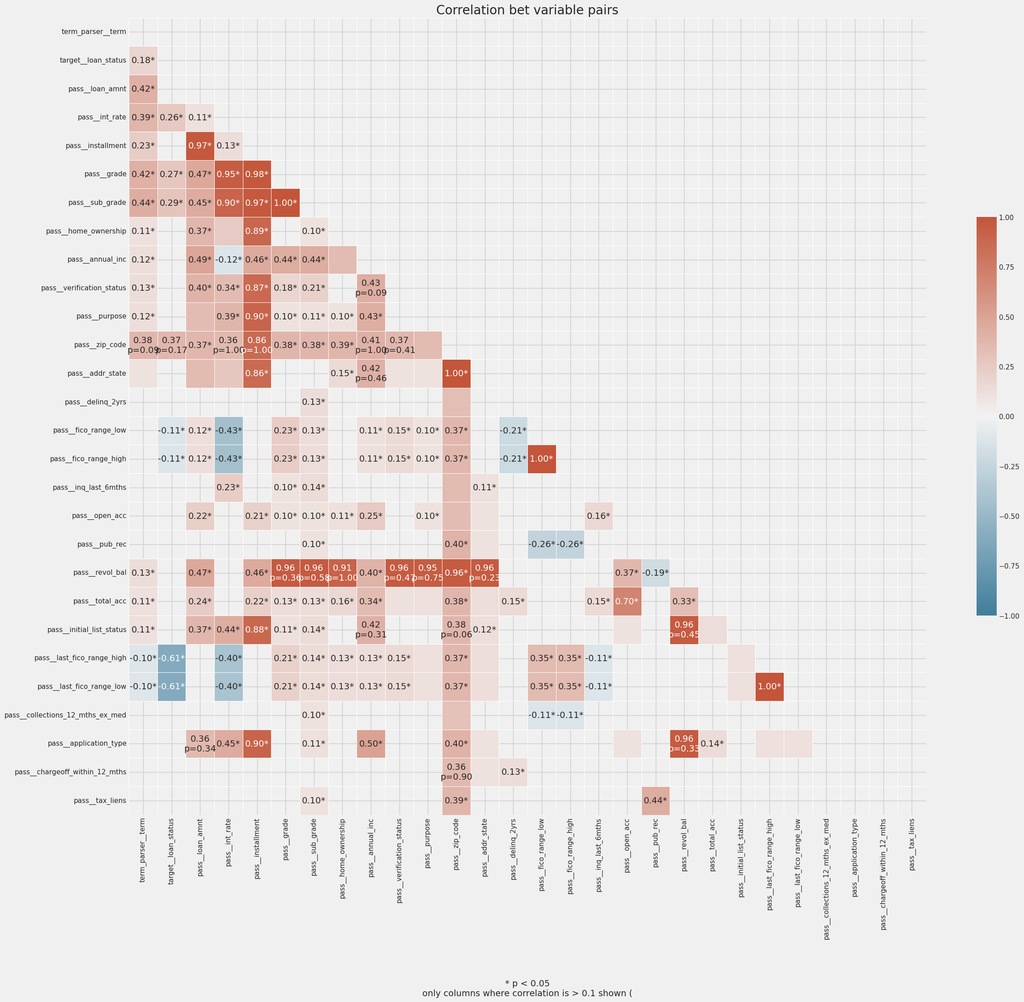

```python
importlib.reload(graph)
graph.render_corr_matrix_based_on_type(source_df.dropna(axis=1, how="any"))
```

*Loan Status* has strong correlation with:

- Applicant FICO (credit) score
- Term of the loan (longer loans are somewhat more to be defaulted on)
- While the correlation with the zip_code is almost 0.4 it is not significant (other variables like grade, sub_grade and interest rate are not included in our model because they are calculated based on estimated loan risk, we could still include them if our goal is to verify the quality of "Lenders Club" estimates we chose not to include them to build a "clean" alternative model using the same source data).

*Loan Grade* and *Interest Rate* have significant correlations with a much larger number of variables:

- Loan Term
- Loan amount and installment size
- FICO score
- Loan purpose
- Applicant income
- Income verification status etc.

This would indicate that the Lenders Club is trying to use a large number of variables to determine the grade and interest rate but that those variables are not necessarily as useful at predicting the likelihood of default.

```
Because the datatypes of features vary we had to use different methods to measure the strength and significance of each pair:

- Chi-Squared Test: Assesses independence between two categorical variables.  For bool-bool pairs due to categorical nature.

- Point Biserial Correlation: Measures correlation between a binary and a continuous variable. For bool-numerical pairs to account for mixed data types.

- Spearman's Rank Correlation: Assesses monotonic relationship between two continuous variables. Used for numerical-numerical pairs (for non-normally distributed data).

Since the Chi-Squared test outputs an unbound statistic/value which can't be directly compared to  pointbiserialr or Spearman Rank we have converted them to a  ` Cramér's V:` value which is normalized between 0 and 1. This was done to make the values in the matrix more uniform however we must note that Cramér's V and Spearman's correlation coefficients are fundamentally different statistics and generally can't be directly compared.
```

### 1.1.1 Relationships between individual variables

This part includes various charts showing the relationships between specific manually selected variables:

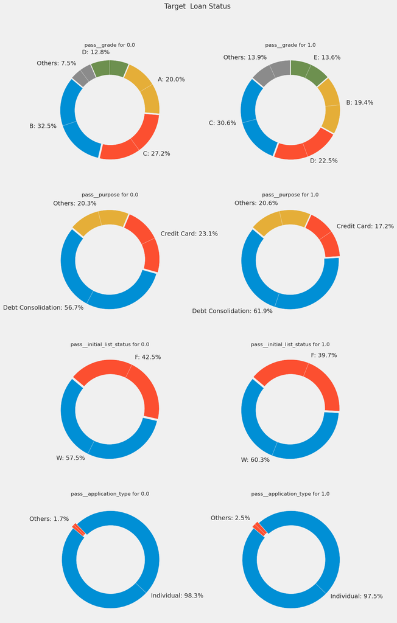

```python
importlib.reload(graph)
graph.draw_distribution_pie_charts(
    source_df,
    split_var="target__loan_status",
    include_cols=[
        "pass__grade",
        "pass__purpose",
        "pass__initial_list_status",
        "pass__application_type",
    ],
)
```

We can see that much fewer grade A and B loans were defaulted on while at C or below the likelihood of default becomes higher than average:

```python
display("Default Rate and Expected Return by Grade:")

from src import utils

importlib.reload(utils)
results = source_df.groupby("pass__grade").apply(utils.calculate_metrics).round(2)

display(results)
```

```
'Default Rate and Expected Return by Grade:'
```

| pass__grade | default_rate | mean_interest_rate | expected_return |
| --- | --- | --- | --- |
| A | 0.07 | 7.09 | 6.60 |
| B | 0.13 | 10.65 | 9.24 |
| C | 0.22 | 14.00 | 10.87 |
| D | 0.31 | 17.79 | 12.23 |
| E | 0.38 | 21.16 | 13.03 |
| F | 0.50 | 25.12 | 12.46 |
| G | 0.57 | 27.74 | 11.98 |

The `expected_return` show the rate of return adjusted by the default rate. e.g. while almost 60% of all `G` grade loans are defaulted on you can still expect to make ~12% per year because the interest is very high. `A` grade loans tend to be relatively much less profitable despite the much lower risk.

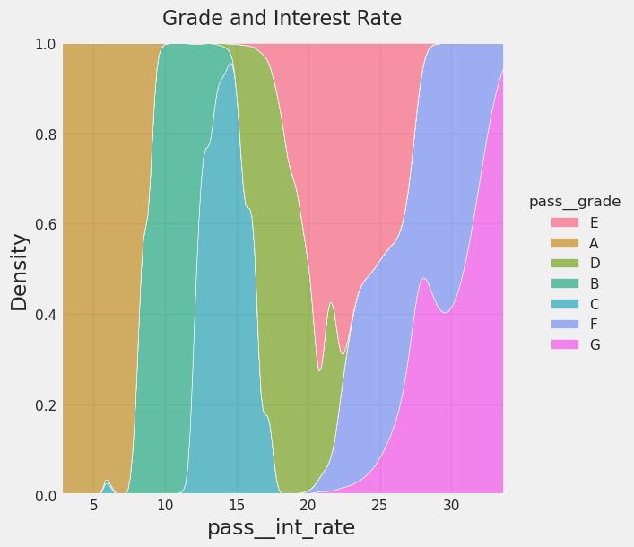

```python
sns.displot(
    data=source_df,
    x="pass__int_rate",
    hue="pass__grade",
    kind="kde",
    height=6,
    multiple="fill",
    # clip=(10, 80),
)
plt.title("Grade and Interest Rate", x=0.5, y=1.025, fontdict={"size": 16})
```

There is quite a bit of overlap between interest rates for lower grades (D+).

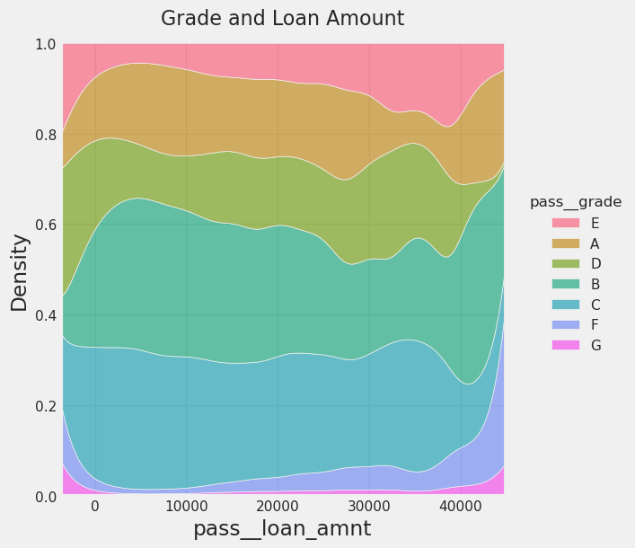

```python
sns.displot(
    data=source_df,
    x="pass__loan_amnt",
    hue="pass__grade",
    kind="kde",
    height=6,
    multiple="fill",
    # clip=(10, 80),
)
plt.title("Grade and Loan Amount", x=0.5, y=1.025, fontdict={"size": 16})
```

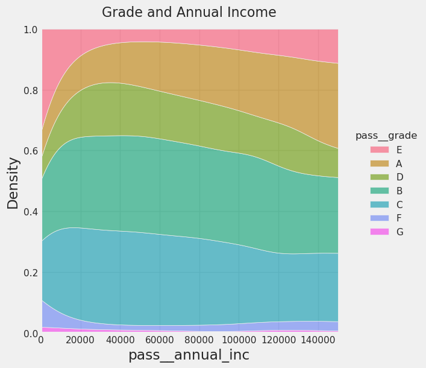

```python
sns.displot(
    data=source_df,
    x="pass__annual_inc",
    hue="pass__grade",
    kind="kde",
    height=6,
    multiple="fill",
    clip=(0, 150000),
)
plt.title("Grade and Annual Income", x=0.5, y=1.025, fontdict={"size": 16})
```

As we would expect the applications by individuals who tend to have very low incomes tend to receive lower grades. However, the rate of `E` grade loans increases significantly along with grade `A` > ~100k yearly income which is quite interesting and requires additional analysis because this does not apply to loans of other grades (we can see in charts below that the income of ~25% applicants is > 90k so this can't really be explained by random variation due to small sample size)

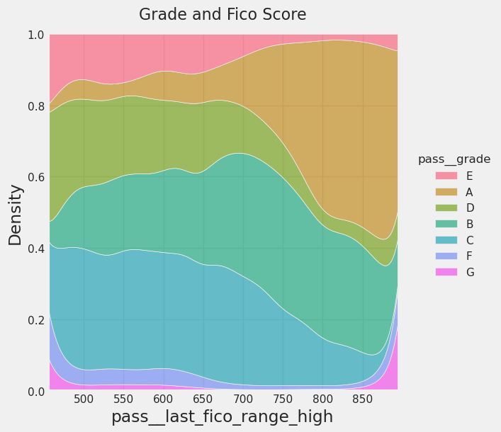

```python
sns.displot(
    data=source_df,
    x="pass__last_fico_range_high",
    hue="pass__grade",
    kind="kde",
    height=6,
    multiple="fill",
    # clip=(10, 80),
)
plt.title("Grade and Fico Score", x=0.5, y=1.025, fontdict={"size": 16})
```

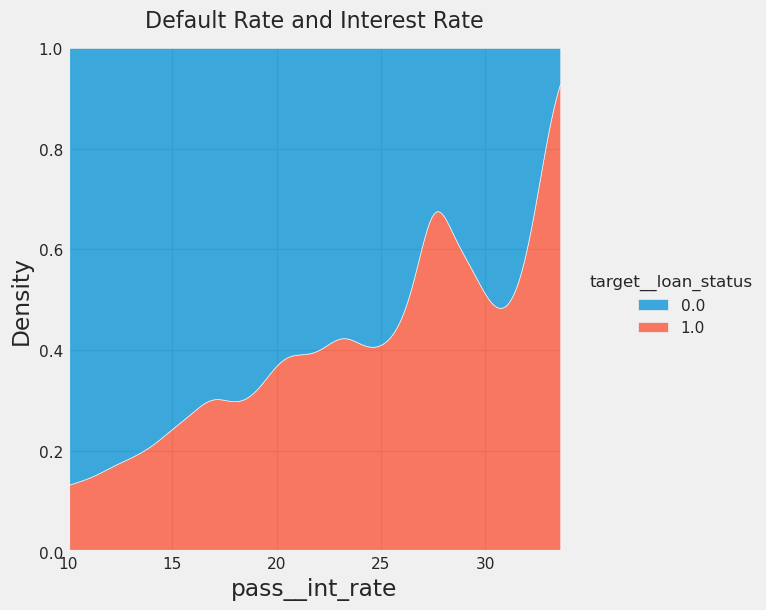

```python
sns.displot(
    data=source_df,
    x="pass__int_rate",
    hue="target__loan_status",
    kind="kde",
    height=6,
    multiple="fill",
    clip=(10, 80),
)
plt.title("Default Rate and Interest Rate", x=0.5, y=1.025, fontdict={"size": 16})
```

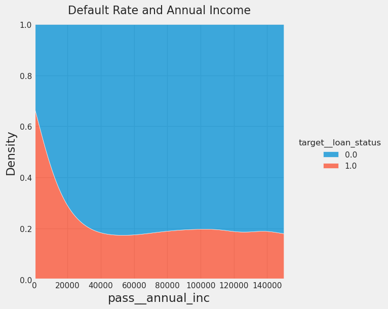

```python
sns.displot(
    data=source_df,
    x="pass__annual_inc",
    hue="target__loan_status",
    kind="kde",
    height=6,
    multiple="fill",
    clip=(0, 150000),
)
plt.title("Default Rate and Annual Income", x=0.5, y=1.025, fontdict={"size": 16})
```

While low income individuals are much more likely to default the risk of default doesen't seems to decrease much or at as income goes up.

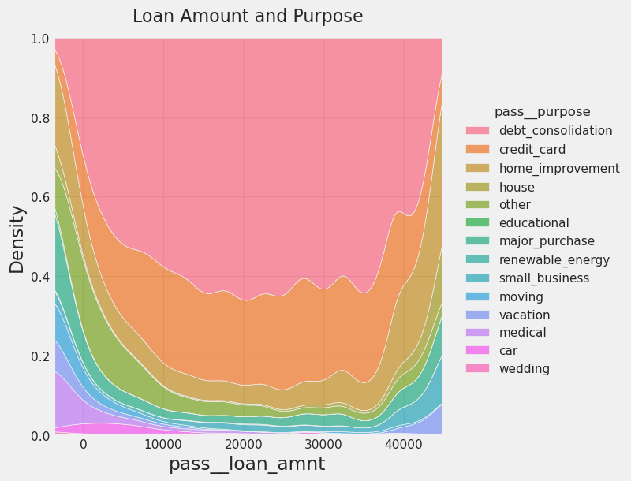

```python
sns.displot(
    data=source_df,
    hue="pass__purpose",
    x="pass__loan_amnt",
    kind="kde",
    height=6,
    multiple="fill",
    # clip=(10, 80),
)
plt.title("Loan Amount and Purpose", x=0.5, y=1.025, fontdict={"size": 16})
```

```python
# TODO: Add more
include_cols = [
    "term_parser__term",
    "target__loan_status",
    "pass__loan_amnt",
    "pass__int_rate",
    # "pass__installment",
    "pass__grade",
    # 'pass__sub_grade',
    "pass__home_ownership",
    "pass__annual_inc",
    # 'pass__verification_status',
    "pass__purpose",
    # 'pass__zip_code',
    # 'pass__addr_state',
    # 'pass__dti',
    # 'pass__delinq_2yrs',
    # 'pass__fico_range_low',
    "pass__fico_range_high",
    # 'pass__inq_last_6mths',
    # 'pass__mths_since_last_delinq',
    # 'pass__mths_since_last_record',
    # 'pass__open_acc',
    # 'pass__pub_rec',
    # 'pass__revol_bal',
    # 'pass__revol_util',
    # 'pass__total_acc',
    # 'pass__initial_list_status',
    "pass__last_fico_range_high",
    # 'pass__last_fico_range_low',
    # 'pass__collections_12_mths_ex_med',
    # 'pass__mths_since_last_major_derog',
    # 'pass__application_type',
    # 'pass__annual_inc_joint',
    # 'pass__dti_joint',
    # 'pass__verification_status_joint',
    # 'pass__inq_fi',
    # 'pass__inq_last_12m',
    # 'pass__chargeoff_within_12_mths',
    # 'pass__mort_acc',
    # 'pass__pub_rec_bankruptcies',
    # 'pass__tax_liens',
    # 'pass__tot_hi_cred_lim',
    # 'pass__total_bal_ex_mort'
]

for c in include_cols:
    print(f"{c}: {source_df[c].dtype}")
```

```
term_parser__term: int64
target__loan_status: float64
pass__loan_amnt: float64
pass__int_rate: float64
pass__grade: object
pass__home_ownership: object
pass__annual_inc: float64
pass__purpose: object
pass__fico_range_high: float64
pass__last_fico_range_high: float64
```

```python
source_df[["term_parser__term"]]
```

|  | term_parser__term |
| --- | --- |
| 1233152 | 60 |
| 461729 | 36 |
| 738295 | 60 |
| 390716 | 36 |
| 350813 | 60 |
| ... | ... |
| 701647 | 36 |
| 1093222 | 36 |
| 1231982 | 36 |
| 143267 | 36 |
| 208225 | 36 |

5361 rows × 1 columns

```python
importlib.reload(stats_utils)
source_df_include_bin = source_df[include_cols]
# Drop annual income outliers
source_df_include_bin = source_df_include_bin[
    source_df_include_bin["pass__annual_inc"] < 500000
    ]

numerical_cols = source_df_include_bin.select_dtypes(
    include=["int64", "float64"]
).columns
categorical_cols = source_df_include_bin.select_dtypes(
    include=["object", "category"]
).columns

binned_df = pd.DataFrame()

# Bin numerical columns and add them to the new DataFrame with dynamic labels
for col in numerical_cols:
    if source_df_include_bin[col].nunique() < 5:
        # Treat as categorical, simply copy it over
        binned_df[f"{col}_binned"] = source_df_include_bin[col].astype("category")
    else:
        binned_df[f"{col}_binned"] = stats_utils.bin_and_label(
            source_df_include_bin[col], num_bins=4
        )  # Adjust num_bins as needed
    binned_df[col] = source_df_include_bin[col]
# Add original categorical columns to the new DataFrame
for col in categorical_cols:
    binned_df[col] = source_df[col]
binned_df.dtypes
```

```
term_parser__term_binned             category
term_parser__term                       int64
target__loan_status_binned           category
target__loan_status                   float64
pass__loan_amnt_binned               category
pass__loan_amnt                       float64
pass__int_rate_binned                category
pass__int_rate                        float64
pass__annual_inc_binned              category
pass__annual_inc                      float64
pass__fico_range_high_binned         category
pass__fico_range_high                 float64
pass__last_fico_range_high_binned    category
pass__last_fico_range_high            float64
pass__grade                            object
pass__home_ownership                   object
pass__purpose                          object
dtype: object
```

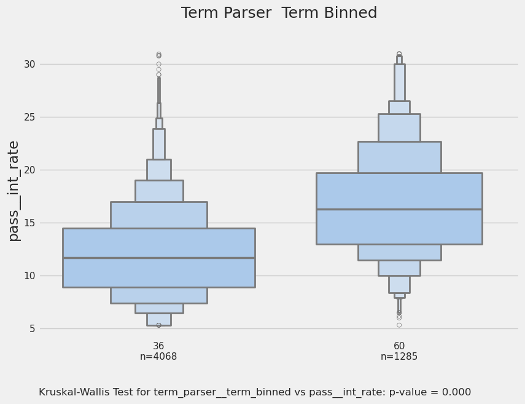

```
None
```

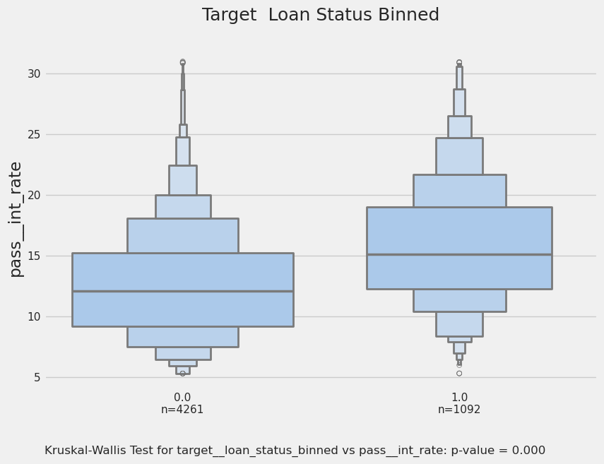

```
None
```

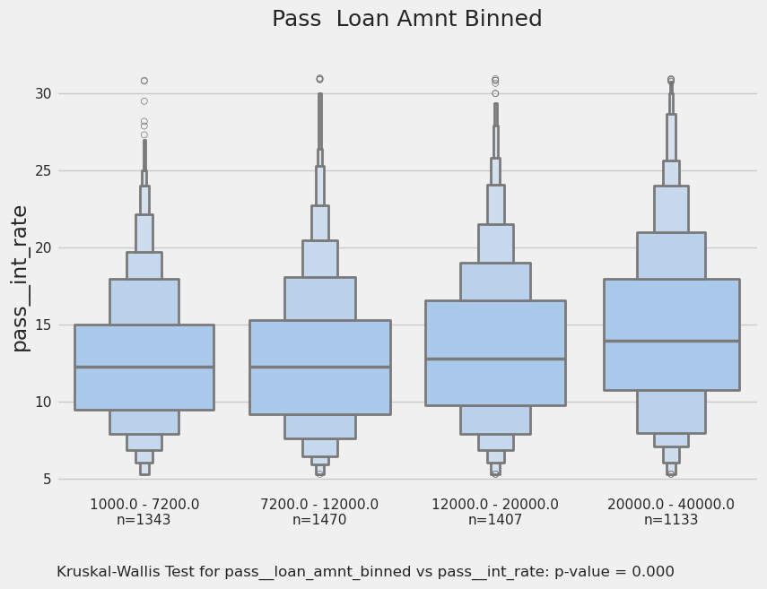

```
None
```

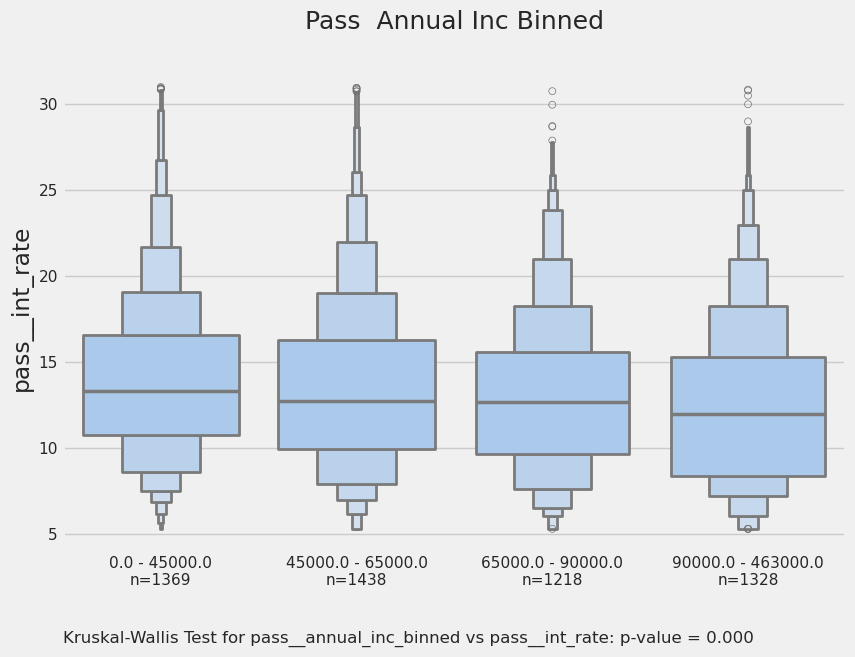

```
None
```

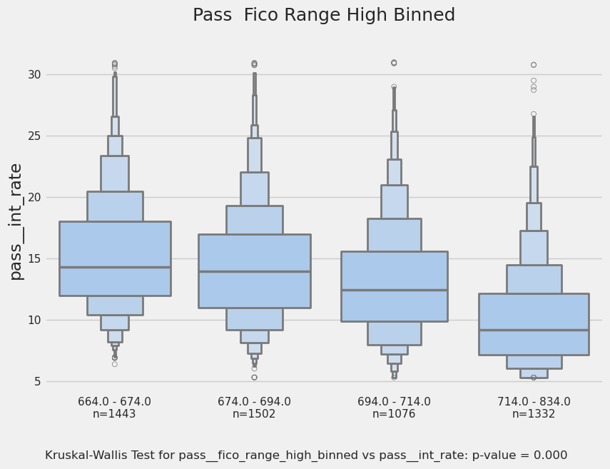

```
None
```

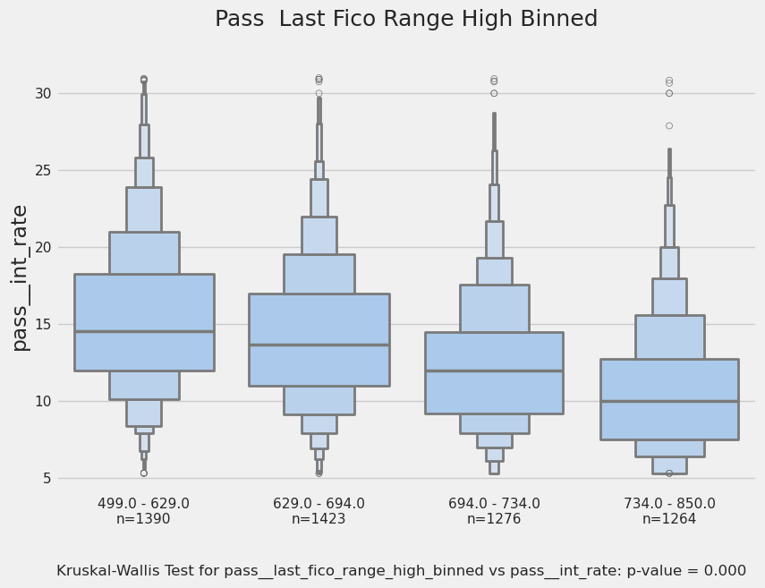

```
None
```

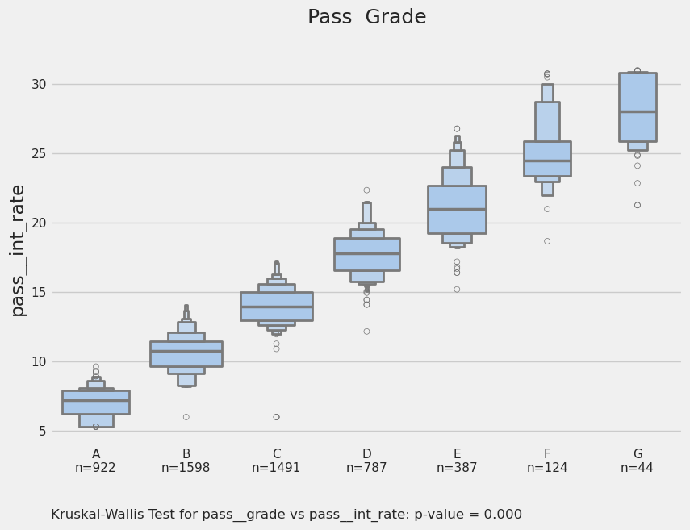

```
None
```

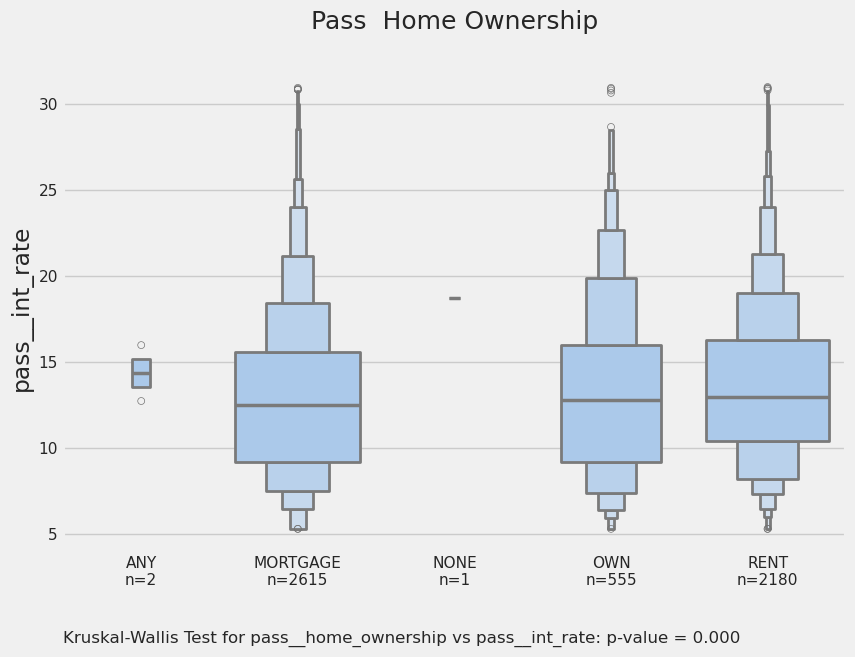

```
None
```

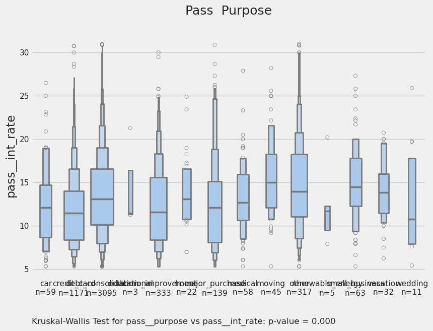

```
None
```

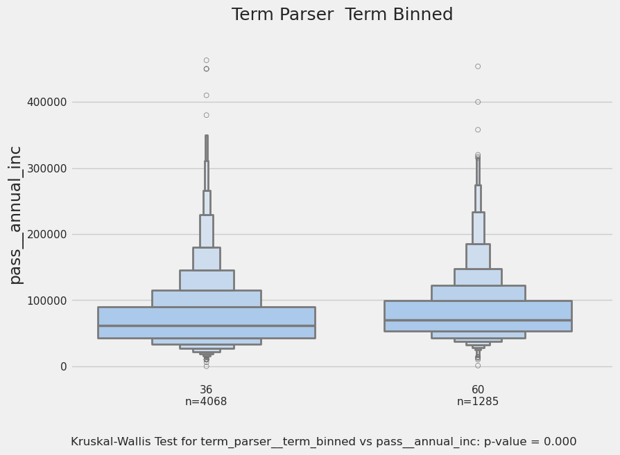

```
None
```

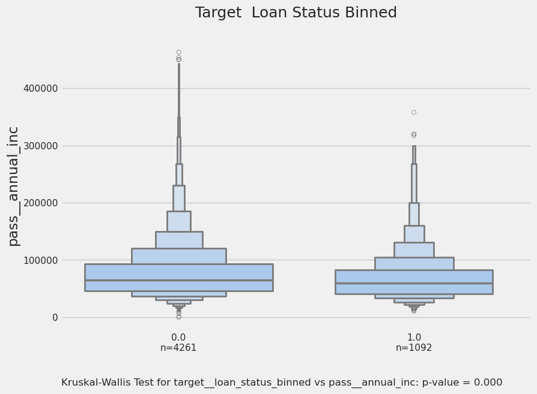

```
None
```

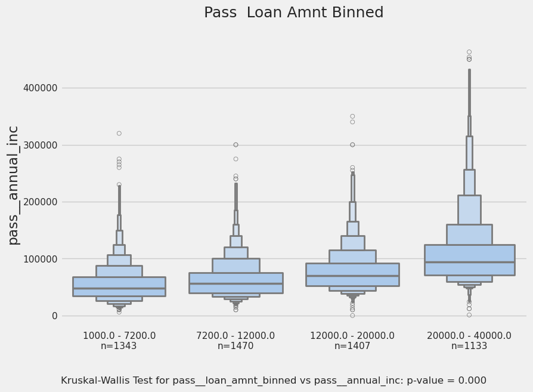

```
None
```

[14 more figures not shown]

```
None
```

```python
importlib.reload(graph)
for target_y in ["pass__int_rate", "pass__annual_inc", "pass__fico_range_high"]:
    for c in binned_df.columns:
        if pd.api.types.is_numeric_dtype(binned_df[c]):
            continue

        if target_y in c and "binned" in c:
            continue
        if VERBOSE:
            display(f"{c} vs {target_y}")
        display(graph.boxen_plot_by_cat(c, binned_df, target_y))
```

```python
source_df["pass__fico_range_high"]
```

```
1233152    714.0
461729     689.0
738295     694.0
390716     704.0
350813     694.0
           ...
701647     719.0
1093222    749.0
1231982    719.0
143267     759.0
208225     664.0
Name: pass__fico_range_high, Length: 5361, dtype: float64
```

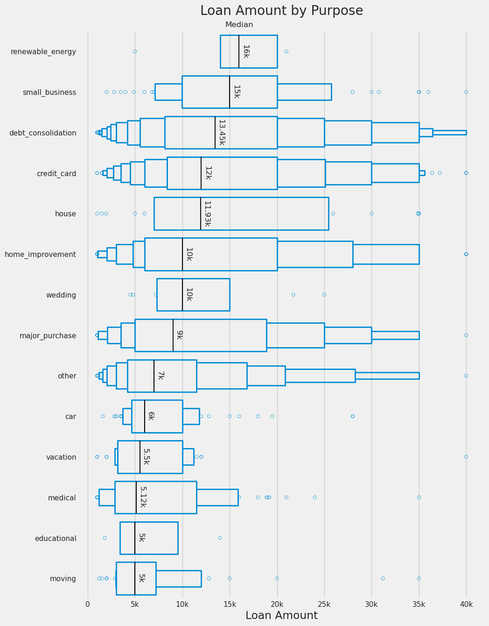

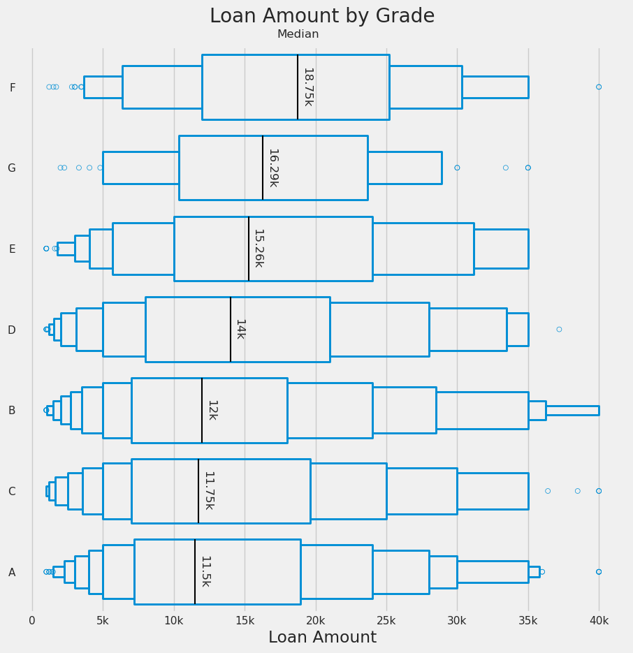

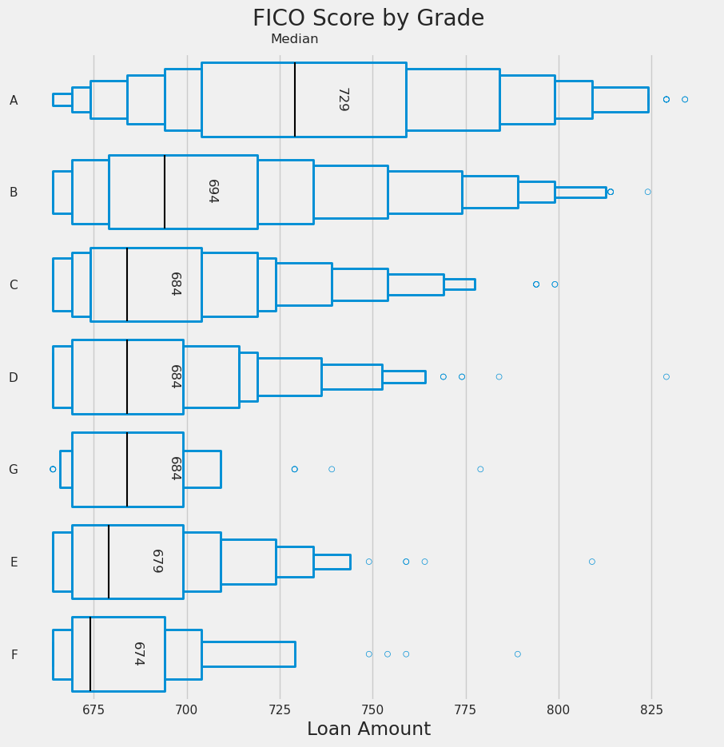

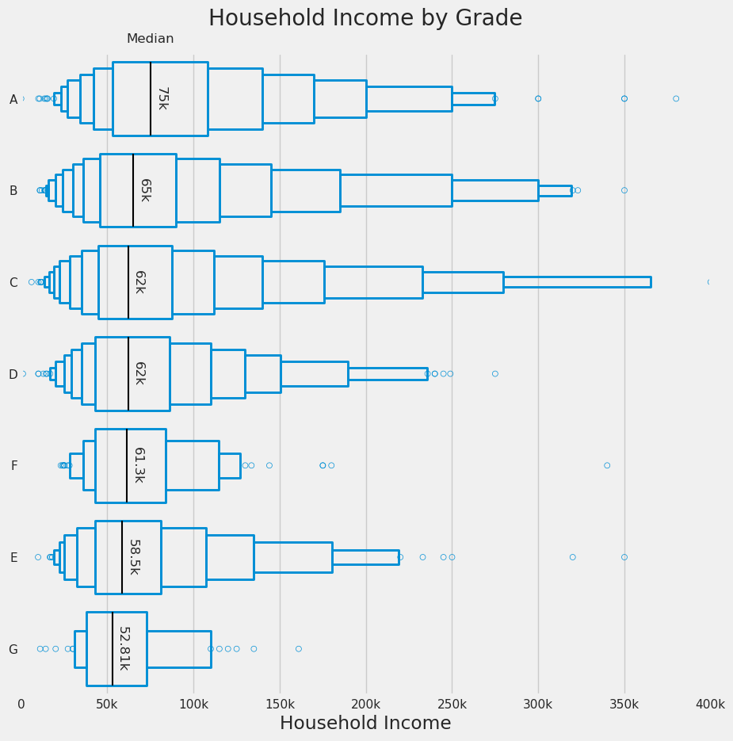

```python
importlib.reload(stats_utils)
importlib.reload(graph)
group_col = "pass__purpose"
target_col = "pass__loan_amnt"

graph.boxen_plots_by_category(
    source_df=source_df,
    group_col="pass__purpose",
    target_col="pass__loan_amnt",
    title="Loan Amount by Purpose",
    x_label="Loan Amount",
)

graph.boxen_plots_by_category(
    source_df=source_df,
    group_col="pass__grade",
    target_col="pass__loan_amnt",
    title="Loan Amount by Grade",
    x_label="Loan Amount",
)
graph.boxen_plots_by_category(
    source_df=source_df,
    group_col="pass__grade",
    target_col="pass__fico_range_high",
    title="FICO Score by Grade",
    x_label="Loan Amount",
)
graph.boxen_plots_by_category(
    source_df=source_df,
    group_col="pass__grade",
    target_col="pass__annual_inc",
    title="Household Income by Grade",
    x_label="Household Income",
    x_range=(0, 400000),
)
```

### 1.2.1 Variable Selection

#### 1.2.2 Population Stability Index

We can use PSI to drop unstable features:

Interpreting PSI Values PSI = 0: No change in the distribution between the two datasets. 0 < PSI < 0.1: Indicates a minor change in distribution. Generally acceptable for most applications. 0.1 ≤ PSI < 0.25: Suggests a medium change, warranting investigation. PSI ≥ 0.25: Represents a significant change in the feature distribution, suggesting that the feature's behavior has altered considerably from the baseline. Features with high PSI are often considered unstable and may be dropped from the model to maintain its performance.

```python
####
from feature_engine.selection import DropHighPSIFeatures
```

```python
len(source_df)
```

```
5361
```

```python
# Drop columns where most values are missing
source_df_psi = source_df.drop(columns=["pass__annual_inc_joint",
                                        "pass__dti_joint",
                                        "pass__verification_status_joint",
                                        "pass__mths_since_last_record",
                                        "pass__mths_since_last_major_derog",
                                        'pass__mths_since_last_delinq'])
source_df_psi = source_df_psi.dropna()
```

```python
transformer = DropHighPSIFeatures(split_frac=0.6)
transformer.fit(source_df_psi)
```

```
DropHighPSIFeatures(split_frac=0.6)
```

```python
transformer.psi_values_
```

```
{'term_parser__term': 0.0,
 'emp_length_parser__emp_length': 0.00741761565898279,
 'target__loan_status': 0.0,
 'pass__loan_amnt': 0.025024201814442776,
 'pass__int_rate': 0.07176711417547209,
 'pass__installment': 0.011609246883005436,
 'pass__annual_inc': 0.03241740868044229,
 'pass__dti': 0.015406464288949512,
 'pass__delinq_2yrs': 0.0057098047008174195,
 'pass__fico_range_low': 0.024401601815981836,
 'pass__fico_range_high': 0.024401601815981836,
 'pass__inq_last_6mths': 0.0004806433251511103,
 'pass__open_acc': 0.020049125901470677,
 'pass__pub_rec': 0.0011239749466162331,
 'pass__revol_bal': 0.012375403776342789,
 'pass__revol_util': 0.010228320444652932,
 'pass__total_acc': 0.012150588779396194,
 'pass__last_fico_range_high': 0.018082420124089962,
 'pass__last_fico_range_low': 0.018082420124089962,
 'pass__collections_12_mths_ex_med': 0.0,
 'pass__inq_fi': 0.013248028575812698,
 'pass__inq_last_12m': 0.024401074697258687,
 'pass__chargeoff_within_12_mths': 0.0,
 'pass__mort_acc': 0.009757189838540613,
 'pass__pub_rec_bankruptcies': 4.868286594901147e-05,
 'pass__tax_liens': 0.0,
 'pass__tot_hi_cred_lim': 0.01626241771088676,
 'pass__total_bal_ex_mort': 0.020408531871268523}
```